# Prediction of the manner in which respondents performed barbell lifts

### Description

Using devices such as Jawbone Up, Nike FuelBand, and Fitbit now it is possible to collect a large amount of data about personal activity relatively inexpensively.  
People regularly quantify how much of a particular activity they do, but they rarely quantify how well they do it. They were asked to perform barbell lifts correctly and incorrectly in 5 different ways. The goal of this project is to use data from accelerometers on the belt, forearm, arm, and dumbell of 6 participants.

### Cleaning data

First of all we need to refine data and prepare the dataset for investigation.  
When I checked out the dataset I found that there are several representations missing values, so taking this into account let’s load the dataset:

```r
if (!file.exists(file.training))
    download.file(url.training, file.training, method = 'curl', quiet = T)

if (!file.exists(file.testing))
    download.file(url.testing, file.testing, method = 'curl', quiet = T)

load.csv <- function(file) {
    read.csv(file,
             header = T,
             na.strings = c(" ", "", "NA"),
             stringsAsFactors = F)
}

training <- load.csv(file.training)
testing  <- load.csv(file.testing)
```

Let’s clear a loaded dataset off the columns that have more than `50%` missing values, rule out duplicated columns and obviously useless columns like observation’s indicies:

```r
cvtd_ts.id <- which(colnames(training) == 'cvtd_timestamp')
problem.id <- which(colnames(testing) == 'problem_id')
na.id <- which(apply(training, 2, function(x) {
    sum(is.na(x))/length(x)
}) > .5)

ids <- c(1, na.id, cvtd_ts.id)

training <- training[, -ids]
testing <- testing[, -c(ids, problem.id)]
```

The last stage of cleaning is a determining and converting classes of predictors:

```r
user_name.id  <- which(colnames(training) == 'user_name')
new_window.id <- which(colnames(training) == 'new_window')
classe.id     <- which(colnames(training) == 'classe')

ids <- c(user_name.id, new_window.id, classe.id)

training[, -ids] <- rapply(training[, -ids], as.numeric)
training[, ids]  <- rapply(training[, ids], as.factor, classes = "character", how = "replace")

testing[, -ids] <- rapply(testing[, -ids], as.numeric)
testing[, ids]  <- rapply(testing[, ids], as.factor, classes = "character", how = "replace")

testing$new_window  <- as.integer(testing$new_window)
training$new_window <- as.integer(training$new_window)
```

### Visualization

In this section I tried to find patterns inside the dataset.  
It’s not so easy because of dataset dimensionality. After cleaning, the dataset has `57` predictors. Despite this fact I found that some predictors show interesting patterns:

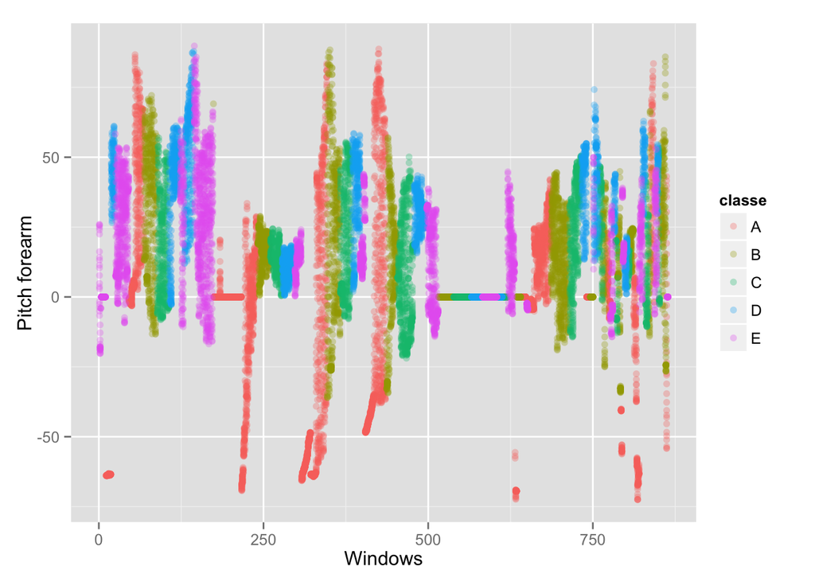

```r
ggplot(data = training) +
    aes(x = num_window, y = pitch_forearm, color = classe) +
    geom_point(alpha=0.3) +
    labs(x = 'Windows', y = 'Pitch forearm')
```

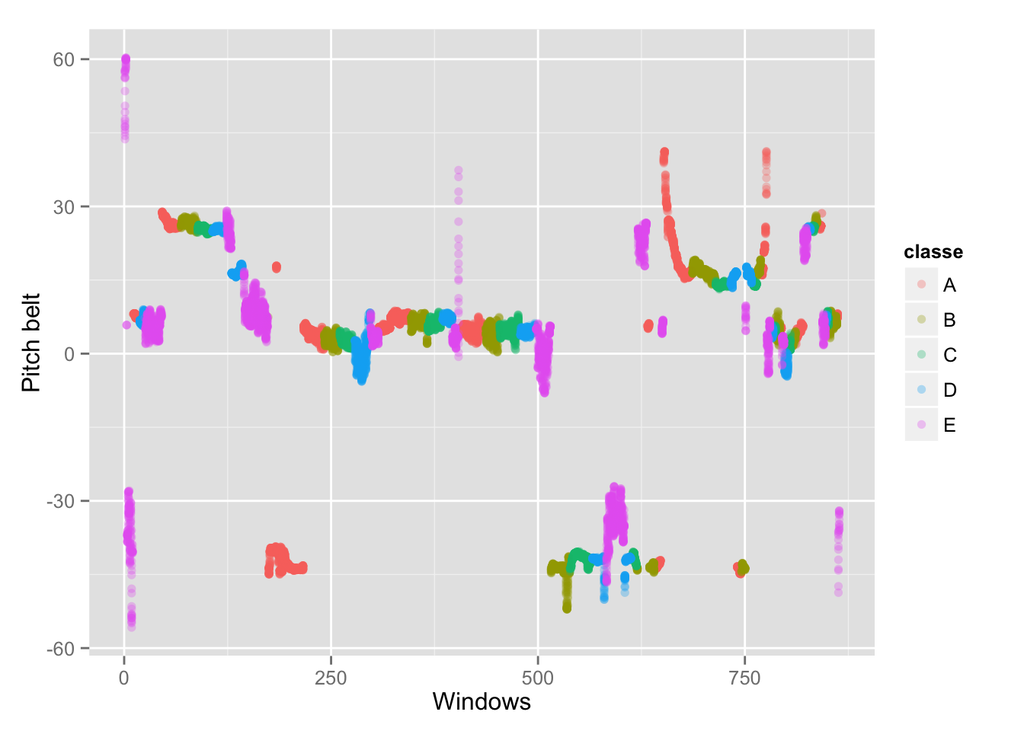

```r
ggplot(data = training) +
    aes(x = num_window, y = pitch_belt, color = classe) +
    geom_point(alpha=0.3) +
    labs(x = 'Windows', y = 'Pitch belt')
```

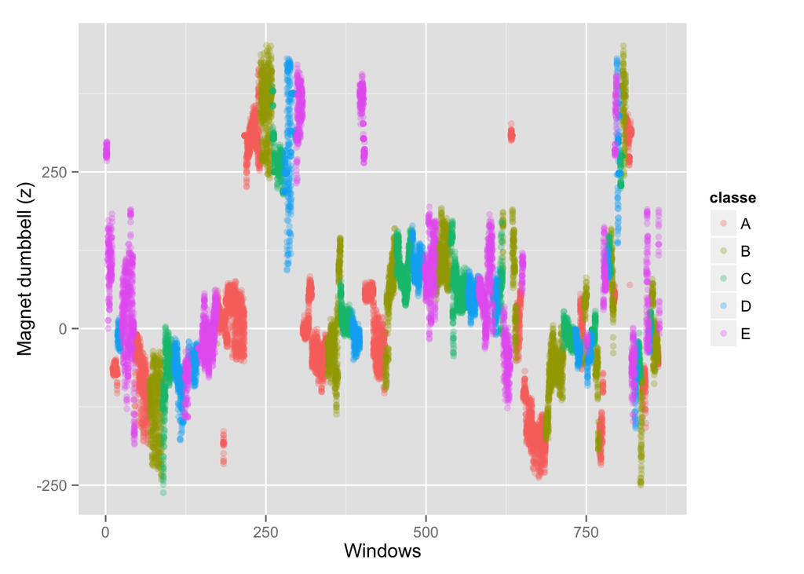

```r
ggplot(data = training) +
    aes(x = num_window, y = magnet_dumbbell_z, color = classe) +
    geom_point(alpha=0.3) +
    labs(x = 'Windows', y = 'Magnet dumbbell (z)')
```

You can notice on graphs that there are a lot of distinguishable spots and stripes belonging to diverse classes. Let’s try to reduce dataset dimensionality, find principal components and look at the pattern shown by first two components:

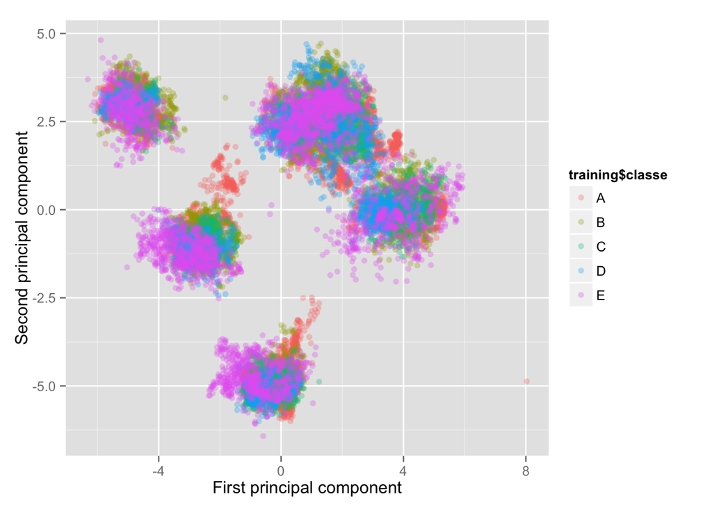

```r
ids <- which(sapply(training, class) == 'factor')
wof.testing  <- testing[, -ids]
wof.training <- training[, -ids]

pca <- preProcess(wof.training, method = 'pca', thresh = .95)
pc.train <- predict(pca, wof.training)
pc.test  <- predict(pca, wof.testing)

ggplot(data = pc.train) +
    aes(x = PC1, y = PC2, color = training$classe) +
    geom_point(alpha=0.3) +
    labs(x = 'First principal component', y = 'Second principal component')
```

As you can see there are five big spots which clearly reveal the pattern. But there is no spot belonging to a single class. Each spot is a mix of different classes.  
Given results of the exploration, it’s certain that dataset is not linearly separable and it’s not an easy task for nonlinear classifiers like the support vector machine thus I decided to use nonparametric model to solve this challenge.

### Random Forest

*Random forest* has a lot of useful features like:

- It runs efficiently on large datasets.
- There is no need for **cross-validation** or a separate test set to get an unbiased estimate of the test set error. It’s estimated internally by the out-of-bag error estimate method.
- There is no need to perform feature selection.
- and other interesting treats.

Fit the random forest with 100 trees and find confustion matrix to see RF’s performance on training dataset:

```r
pml.rf <- randomForest(classe ~ ., data = training, ntree = 100)
pml.rf
```

[output not shown]

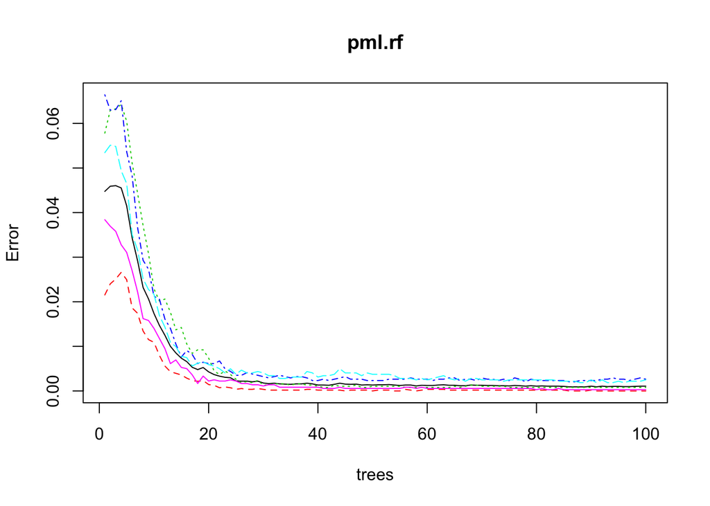

```r
plot(pml.rf)
```

Build a confusion matrix to check how obtained random forest works on testing data:

```r
confusionMatrix(testing$classe, predict(pml.rf, testing))
```

```
## Confusion Matrix and Statistics
##
##           Reference
## Prediction A B C D E
##          A 7 0 0 0 0
##          B 0 8 0 0 0
##          C 0 0 1 0 0
##          D 0 0 0 1 0
##          E 0 0 0 0 3
##
## Overall Statistics
##
##                Accuracy : 1
##                  95% CI : (0.832, 1)
##     No Information Rate : 0.4
##     P-Value [Acc > NIR] : 1.1e-08
##
##                   Kappa : 1
##  Mcnemar's Test P-Value : NA
##
## Statistics by Class:
##
##                      Class: A Class: B Class: C Class: D Class: E
## Sensitivity              1.00      1.0     1.00     1.00     1.00
## Specificity              1.00      1.0     1.00     1.00     1.00
## Pos Pred Value           1.00      1.0     1.00     1.00     1.00
## Neg Pred Value           1.00      1.0     1.00     1.00     1.00
## Prevalence               0.35      0.4     0.05     0.05     0.15
## Detection Rate           0.35      0.4     0.05     0.05     0.15
## Detection Prevalence     0.35      0.4     0.05     0.05     0.15
## Balanced Accuracy        1.00      1.0     1.00     1.00     1.00
```

One of the pros of random forest algorithm is that it can produce vector of predictor importance:

```r
imp <- importance(pml.rf)
head(imp[order(imp[, 1], decreasing = TRUE), ])
```

```
## raw_timestamp_part_1           num_window            roll_belt
##               1898.5               1079.2                995.5
##             yaw_belt    magnet_dumbbell_z           pitch_belt
##                728.9                626.8                608.8
```

### Stochastic gradient boosting

*Stochastic gradient boosting* is invented by Friedman as a modification of gradient boosting algorithm. It produces a model in form of an ensemble of weak prediction models like decision trees. Like in *RF*, this algorithm allows to define OOB estimate of the prediction performance, but in this case I’m going to use 5-fold cross-validation to determine tuninig parameters of *gmb* and an expected accuracy:

```r
tr.ctrl <- trainControl(method = 'cv', number = 5, verboseIter = F)
pml.gbm <- train(classe ~., method = 'gbm', trControl = tr.ctrl, data = training, verbose = F)
pml.gbm
```

[output not shown]

The graph below shows how a change in an estimated accuracy depends on the parameters - number of interations of boosting, tree’s depth:

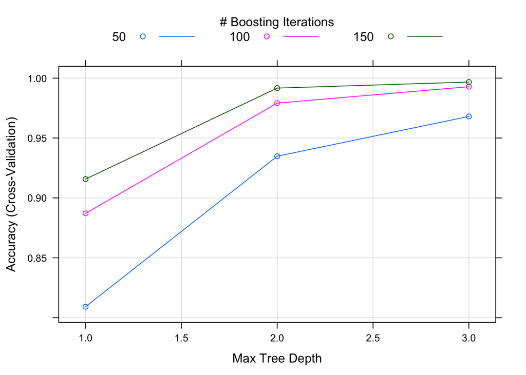

```r
plot(pml.gbm)
```